# EasyVisa Project

## Data Preprocessing

- Missing value treatment (if needed)
- Feature engineering
- Outlier detection and treatment (if needed)
- Preparing data for modeling
- Any other preprocessing steps (if needed)

### Missing Value Treatment

```python
# Checking for any missing values
df1.isnull().sum()
```

```
case_id                  0
continent                0
education_of_employee    0
has_job_experience       0
requires_job_training    0
no_of_employees          0
yr_of_estab              0
region_of_employment     0
prevailing_wage          0
unit_of_wage             0
full_time_position       0
case_status              0
dtype: int64
```

#### There are no missing values so there is no missing value treatments need to happen.

### Feature Engineering

- Looking at the features in the the datase, there are no obvious features to create/derive from the existing features.
- Therefore, no feature engineering will be performed.

### Outlier detection and treatment (if needed)

```
['no_of_employees', 'yr_of_estab', 'prevailing_wage']
```

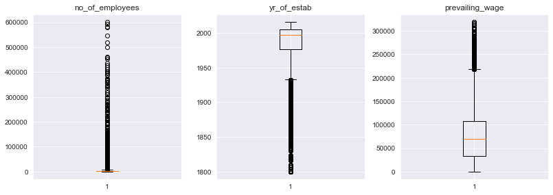

```python
# Outlier detection using boxplot
numeric_columns = df1.select_dtypes(include=np.number).columns.tolist()

print(numeric_columns)

plt.figure(figsize=(15, 15))

for i, variable in enumerate(numeric_columns):
    plt.subplot(4, 4, i + 1)
    plt.boxplot(df1[variable], whis=1.5)
    plt.tight_layout()
    plt.title(variable)

plt.show()
```

- Per the plots above, there are outliers when visually looking at different numeric features.
- Since these outliers are from previous visa case status data provided by Office of Foreign Labor Certification (OFLC), the outliers do play a role in determining the status of a visa since this is genuine data.
- Therefore the outliers won't be dropped.

### Additional Data Preprocessing

- As seen earlier, the number of employees had a negative value. Going to check the dataframe numerical columns to verify if there are any negative values and if negative, will take the absolute value.

```python
# Checking if there are any additional negative values (for the numerical columns) in the dataframe
numeric_col = ["no_of_employees", "yr_of_estab", "prevailing_wage"]
(df1[numeric_col] < 0).values.any()
```

```
True
```

```python
# Now that it is been confirmed that at least one of the numeric columns has a negative value, going to determine how many in each column
# Checking to see if there are negative values and how many in no_of_employees
(df1["no_of_employees"] < 0).value_counts()
```

```
False    25447
True        33
Name: no_of_employees, dtype: int64
```

```python
# Per the check, there are 33 values for no_of_employees that is negative. This was probably due to a data entry error. Going to use absolute value to convert all negatives to positives.
df1["no_of_employees"] = df1["no_of_employees"].abs()
```

```python
# Verifying there are no more negative values in no_of_employees
(df1["no_of_employees"] < 0).value_counts()
```

```
False    25480
Name: no_of_employees, dtype: int64
```

```python
# Checking to see if there are negative values and how many in yr_of_estab
(df1["yr_of_estab"] < 0).value_counts()
```

```
False    25480
Name: yr_of_estab, dtype: int64
```

```python
# Checking to see if there are negative values and how many in prevailing_wage
(df1["prevailing_wage"] < 0).value_counts()
```

```
False    25480
Name: prevailing_wage, dtype: int64
```

#### no_of_employees was the only numeric column that had negative values, it had 33 total. Used abs() to take the absolute value of all values and verified that no_of_employees no longer has any negative values.

## EDA

- It is a good idea to explore the data once again after manipulating it.

### Univariate Analysis (only on no_of_employees)

```python
# number of employees of company applying for visa
# Since the values for number of employees is too many for a barplot, displaying values sorted in descending order
df1.no_of_employees.sort_values(ascending=False)
```

```
21339    602069
1345     594472
20345    581468
11317    579004
9587     547172
          ...
16157        11
17006        11
14726        11
23186        11
378          11
Name: no_of_employees, Length: 25480, dtype: int64
```

```python
df1.no_of_employees.min()
```

```
11
```

```python
df1.no_of_employees.max()
```

```
602069
```

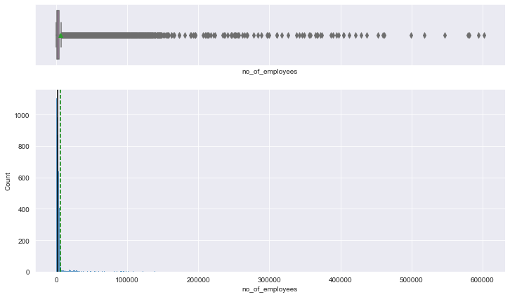

```python
# Number of employees at company applying for visa histogram and boxplot
histogram_boxplot(df1, "no_of_employees")
```

### Observation for no_of_employees

- No real changes to the boxplot. The only difference is now the mininum number of employees a company applying for visas has is 11.

### Bivariate Analysis (only on no_of_employees)

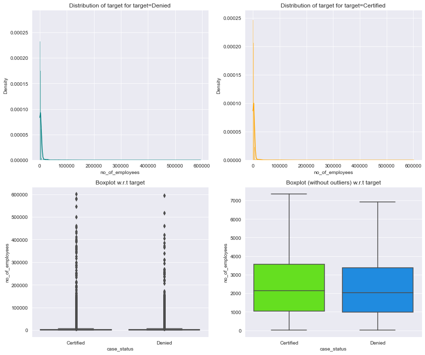

```python
# case_status vs no_of_employees distribution plot
distribution_plot_wrt_target(df1, "no_of_employees", "case_status")
```

### Observation for case_status vs no_of_employees

- No noticeable difference after taking absolute values for all values.

### Preparing the data for modeling

```python
# Creating a copy of dataframe to use for modeling
df2 = df1.copy()

# Dropping "case_id" from dataframe since it is nominal variable that is unique for each visa case and doesn't have any predictive power.
df2 = df2.drop("case_id", axis = 1)
```

### Splitting Data

- Since there is a significant imbalance in the distribution of the target class (`case_status`), going to use stratified sampling to ensure that relative class frequencies are approximately preserved in train and test sets.
- Going to use the `stratify` parameter in the train_test_split function.

```python
# Splitting data
X = df2.drop(["case_status"],axis = 1)

# Using lambda function to make the Denied class equal to 0, and the Certified (Approved) class equal to 1
y = df2["case_status"].apply(lambda x : 1 if x == "Certified" else 0)

# Creating dummy variables for categorical columns
X = pd.get_dummies(X,drop_first = True)
```

```python
# Splitting data into training and test set:
X_train, X_test, y_train, y_test = train_test_split(X, y, test_size = 0.3, random_state = 1, stratify = y)
print(X_train.shape, X_test.shape)
```

```
(17836, 21) (7644, 21)
```

```python
y.value_counts(1)
```

```
1    0.667896
0    0.332104
Name: case_status, dtype: float64
```

```python
y_test.value_counts(1)
```

```
1    0.667844
0    0.332156
Name: case_status, dtype: float64
```

### Defining functions for getting metrics on the model

```python
# defining a function to compute different metrics to check performance of a classification model built using sklearn
def model_performance_classification_sklearn(model, predictors, target):
    """
    Function to compute different metrics to check classification model performance

    model: classifier
    predictors: independent variables
    target: dependent variable
    """

    # predicting using the independent variables
    pred = model.predict(predictors)

    acc = accuracy_score(target, pred)  # to compute Accuracy
    recall = recall_score(target, pred)  # to compute Recall
    precision = precision_score(target, pred)  # to compute Precision
    f1 = f1_score(target, pred)  # to compute F1-score

    # creating a dataframe of metrics
    df_perf = pd.DataFrame(
        {
            "Accuracy": acc,
            "Recall": recall,
            "Precision": precision,
            "F1": f1,
        },
        index=[0],
    )

    return df_perf
```

```python
def confusion_matrix_sklearn(model, predictors, target):
    """
    To plot the confusion_matrix with percentages

    model: classifier
    predictors: independent variables
    target: dependent variable
    """
    y_pred = model.predict(predictors)
    cm = confusion_matrix(target, y_pred)
    labels = np.asarray(
        [
            ["{0:0.0f}".format(item) + "\n{0:.2%}".format(item / cm.flatten().sum())]
            for item in cm.flatten()
        ]
    ).reshape(2, 2)

    plt.figure(figsize=(6, 4))
    sns.heatmap(cm, annot=labels, fmt="")
    plt.ylabel("True label")
    plt.xlabel("Predicted label")
```

## Building bagging and boosting models

## Bagging

### Decision Tree

- The model will be built using the DecisionTreeClassifier function. Using default 'gini' criteria to split.
- Since the classes are imbalanced, a dictionary {0:0.67, 1:0.33} to the model to specify the weight of each class and the decision tree will give more weightage to class 0.
- class_weight is a hyperparameter for the decision tree classifier.

```python
# Building the decision tree with the class weight of {0:0.67, 1:0.33}
dtree = DecisionTreeClassifier(criterion = "gini", class_weight = {0:0.67, 1:0.33}, random_state = 1)
```

```python
# Fitting the decision tree
dtree.fit(X_train, y_train)
```

```
DecisionTreeClassifier(class_weight={0: 0.67, 1: 0.33}, random_state=1)
```

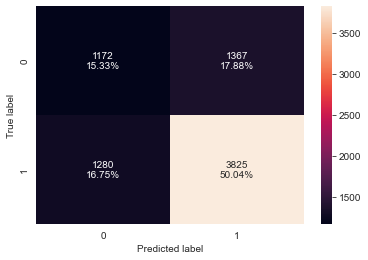

```python
# Building a confusion matrix for the decision tree
confusion_matrix_sklearn(dtree, X_test, y_test)
```

**Explanation of the Confusion Matrix**

```python
# Decision Tree Model Performance Metrics on Training Data
dtree_model_train_perf = model_performance_classification_sklearn(dtree, X_train, y_train)
print("Training performance \n", dtree_model_train_perf)
```

```
Training performance
    Accuracy  Recall  Precision   F1
0       1.0     1.0        1.0  1.0
```

```python
# Decision Tree Model Performance Metrics on Test Data
dtree_model_test_perf = model_performance_classification_sklearn(dtree, X_test, y_test)
print("Testing performance \n", dtree_model_test_perf)
```

```
Testing performance
    Accuracy    Recall  Precision        F1
0  0.653715  0.749265    0.73671  0.742935
```

### The decision tree is working well on the training data (suggesting that the model is overfitting on training data) but is not able to generalize well on the test data concerning Accuracy, Recall, Precision, and F1. There is a steep drop off in those metrics when compared to the the results on the training data.

### Bagging Classifier

```python
# Building and fitting a bagging classifier
bagging = BaggingClassifier(random_state = 1)
bagging.fit(X_train, y_train)
```

```
BaggingClassifier(random_state=1)
```

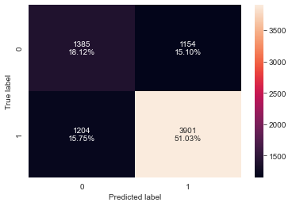

```python
# Building a confusion matrix for the bagging classifier
confusion_matrix_sklearn(bagging, X_test, y_test)
```

```python
# Bagging Classifier Model Performance Metrics on Training Data
bagging_model_train_perf = model_performance_classification_sklearn(bagging, X_train, y_train)
print("Training performance \n", bagging_model_train_perf)
```

```
Training performance
    Accuracy    Recall  Precision        F1
0  0.985198  0.985982    0.99181  0.988887
```

```python
# Bagging Classifier Model Performance Metrics on Test Data
bagging_model_test_perf = model_performance_classification_sklearn(bagging, X_test, y_test)
print("Testing performance \n", bagging_model_test_perf)
```

```
Testing performance
    Accuracy    Recall  Precision        F1
0  0.691523  0.764153   0.771711  0.767913
```

### The bagging classifier is working well on the training data (suggesting that the model is overfitting on training data) but is not able to generalize well on the test data concerning Accuracy, Recall, Precision, and F1. There is a steep drop off in those metrics when compared to the the results on the training data.

### Weighted Bagging Classifier

```python
# Building and fitting a weighted bagging classifier
bagging_wt = BaggingClassifier(base_estimator = DecisionTreeClassifier(criterion = "gini", class_weight = {0:0.67, 1:0.33}, random_state = 1), random_state = 1)
bagging_wt.fit(X_train, y_train)
```

```
BaggingClassifier(base_estimator=DecisionTreeClassifier(class_weight={0: 0.67,
                                                                      1: 0.33},
                                                        random_state=1),
                  random_state=1)
```

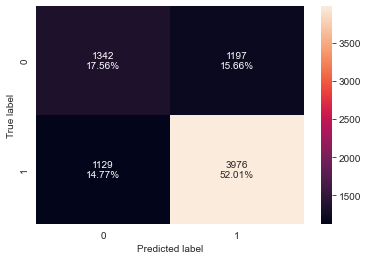

```python
# Building a confusion matrix for the weighted bagging_classifier
confusion_matrix_sklearn(bagging_wt, X_test, y_test)
```

```python
# Weighted Bagging Classifier Model Performance Metrics on Training Data
bagging_wt_model_train_perf = model_performance_classification_sklearn(bagging_wt, X_train, y_train)
print("Training performance \n", bagging_wt_model_train_perf)
```

```
Training performance
    Accuracy    Recall  Precision        F1
0  0.985479  0.987241   0.990984  0.989109
```

```python
# Weighted Bagging Classifier Model Performance Metrics on Test Data
bagging_wt_model_test_perf = model_performance_classification_sklearn(bagging_wt, X_test, y_test)
print("Testing performance \n", bagging_wt_model_test_perf)
```

```
Testing performance
    Accuracy    Recall  Precision        F1
0  0.695709  0.778844   0.768606  0.773691
```

### The weighted bagging classifier is working well on the training data (suggesting that the model is overfitting on training data) but is not able to generalize well on the test data concerning Accuracy, Recall, Precision, and F1. There is a steep drop off in those metrics when compared to the the results on the training data.

### Random Forest

```python
# Building and fitting a random forest classifier
rf = RandomForestClassifier(random_state = 1)
rf.fit(X_train, y_train)
```

```
RandomForestClassifier(random_state=1)
```

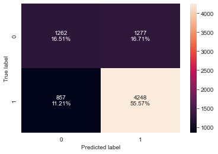

```python
# Building a confusion matrix for the random forest classifier
confusion_matrix_sklearn(rf, X_test, y_test)
```

```python
# Random Forest Classifier Model Performance Metrics on Training Data
rf_model_train_perf = model_performance_classification_sklearn(rf, X_train, y_train)
print("Training performance \n", rf_model_train_perf)
```

```
Training performance
    Accuracy    Recall  Precision        F1
0  0.999944  0.999916        1.0  0.999958
```

```python
# Random Forest Classifier Model Performance Metrics on Test Data
rf_model_test_perf = model_performance_classification_sklearn(rf, X_test, y_test)
print("Testing performance \n", rf_model_test_perf)
```

```
Testing performance
    Accuracy    Recall  Precision        F1
0  0.720827  0.832125   0.768869  0.799247
```

### The random forest classifier is working well on the training data (suggesting that the model is overfitting on training data) but is not able to generalize well on the test data concerning Accuracy, Recall, Precision, and F1. There is a steep drop off in those metrics when compared to the the results on the training data.

### Weighted Random Forest

```python
# Building and fitting a weighted random forest classifier
rf_wt = RandomForestClassifier(class_weight = {0:0.67, 1:0.33}, random_state = 1)
rf_wt.fit(X_train, y_train)
```

```
RandomForestClassifier(class_weight={0: 0.67, 1: 0.33}, random_state=1)
```

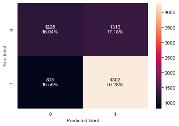

```python
# Building a confusion matrix for the weighted random forest classifier
confusion_matrix_sklearn(rf_wt, X_test, y_test)
```

```python
# Weighted Random Forest Classifier Model Performance Metrics on Training Data
rf_wt_model_train_perf = model_performance_classification_sklearn(rf_wt, X_train, y_train)
print("Training performance \n", rf_wt_model_train_perf)
```

```
Training performance
    Accuracy  Recall  Precision   F1
0       1.0     1.0        1.0  1.0
```

```python
# Weighted Random Forest Classifier Model Performance Metrics on Test Data
rf_wt_model_test_perf = model_performance_classification_sklearn(rf_wt, X_test, y_test)
print("Testing performance \n", rf_wt_model_test_perf)
```

```
Testing performance
    Accuracy    Recall  Precision        F1
0  0.723182  0.842703   0.766162  0.802612
```

### The weighted random forest classifier is working well on the training data (suggesting that the model is overfitting on training data) but is not able to generalize well on the test data concerning Accuracy, Recall, Precision, and F1. There is a steep drop off in those metrics when compared to the the results on the training data.

### Looking at how the all five of the models did on training vs test data, all five models performed poorly on test data suggesting the models trained on test data are overfitted. Going to see if tuning hyperparameters will improve performance.

## Boosting

### Adaboost Classifier

```python
# Building and fitting the model
ab_classifier = AdaBoostClassifier(random_state = 1)
ab_classifier.fit(X_train, y_train)
```

```
AdaBoostClassifier(random_state=1)
```

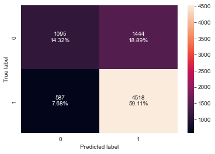

```python
# Building a confusion matrix for the Adaboost classifier
confusion_matrix_sklearn(ab_classifier, X_test, y_test)
```

```python
# Adaboost Classifier Model Performance Metrics on Training Data
ab_classifier_model_train_perf = model_performance_classification_sklearn(ab_classifier, X_train, y_train)
print("Training performance \n", ab_classifier_model_train_perf)
```

```
Training performance
    Accuracy    Recall  Precision       F1
0  0.738226  0.887182   0.760688  0.81908
```

```python
# Adaboost Classifier Model Performance Metrics on Test Data
ab_classifier_model_test_perf = model_performance_classification_sklearn(ab_classifier, X_test, y_test)
print("Testing performance \n", ab_classifier_model_test_perf)
```

```
Testing performance
    Accuracy    Recall  Precision        F1
0  0.734301  0.885015   0.757799  0.816481
```

### The AdaBoost Classifier does okay on training data. The metrics are identical on both training and test data, suggesting the model is well generalized.

### Gradient Boosting Classifier

```python
# Building and fitting the model
gb_classifier = GradientBoostingClassifier(random_state = 1)
gb_classifier.fit(X_train, y_train)
```

```
GradientBoostingClassifier(random_state=1)
```

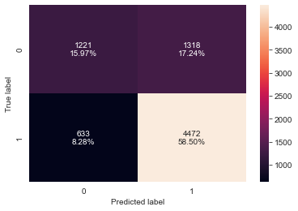

```python
# Building a confusion matrix for the Gradient Boosting classifier
confusion_matrix_sklearn(gb_classifier, X_test, y_test)
```

```python
# Gradient Boosting Classifier Model Performance Metrics on Training Data
gb_classifier_model_train_perf = model_performance_classification_sklearn(gb_classifier, X_train, y_train)
print("Training performance:\n", gb_classifier_model_train_perf)
```

```
Training performance:
    Accuracy   Recall  Precision        F1
0  0.758802  0.88374   0.783042  0.830349
```

```python
# Gradient Boosting Classifier Model Performance Metrics on Test Data
gb_classifier_model_test_perf = model_performance_classification_sklearn(gb_classifier, X_test, y_test)
print("Testing performance:\n", gb_classifier_model_test_perf)
```

```
Testing performance:
    Accuracy    Recall  Precision        F1
0  0.744767  0.876004   0.772366  0.820927
```

### The GradientBoosting Classifier does okay on training data. The metrics are identical on both training and test data, suggesting the model is well generalized.

### XGBoost Classifier

```python
# Fitting the model
xgb_classifier = XGBClassifier(random_state = 1, eval_metric = 'logloss')
xgb_classifier.fit(X_train, y_train)
```

```
XGBClassifier(base_score=0.5, booster='gbtree', colsample_bylevel=1,
              colsample_bynode=1, colsample_bytree=1, enable_categorical=False,
              eval_metric='logloss', gamma=0, gpu_id=-1, importance_type=None,
              interaction_constraints='', learning_rate=0.300000012,
              max_delta_step=0, max_depth=6, min_child_weight=1, missing=nan,
              monotone_constraints='()', n_estimators=100, n_jobs=12,
              num_parallel_tree=1, predictor='auto', random_state=1,
              reg_alpha=0, reg_lambda=1, scale_pos_weight=1, subsample=1,
              tree_method='exact', validate_parameters=1, verbosity=None)
```

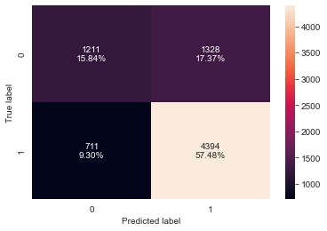

```python
# Building a confusion matrix for the XGBoost classifier
confusion_matrix_sklearn(xgb_classifier, X_test, y_test)
```

```python
# XGBoost Classifier Model Performance Metrics on Training Data
xgb_classifier_model_train_perf = model_performance_classification_sklearn(xgb_classifier, X_train, y_train)
print("Training performance:\n", xgb_classifier_model_train_perf)
```

```
Training performance:
    Accuracy    Recall  Precision        F1
0  0.838753  0.931419   0.843482  0.885272
```

```python
# XGBoost Classifier Model Performance Metrics on Test Data
xgb_classifier_model_test_perf = model_performance_classification_sklearn(xgb_classifier, X_test, y_test)
print("Testing performance:\n", xgb_classifier_model_test_perf)
```

```
Testing performance:
    Accuracy    Recall  Precision        F1
0  0.733255  0.860725   0.767913  0.811675
```

### The XGBoost Classifier does better on training data than the AdaBoost and GradientBoost models, however, when it sees the test data, it performs about the same as the AdaBoost and GradientBoost models do. The model is generalized, however on test data, there is drop off in Recall, Precision, and F1 when compared to the performance on the training data.

## Will tuning the hyperparameters improve the model performance?

## Bagging

### Using GridSearch for Hyperparameter tuning model

- Hyperparameter tuning is tricky in the sense that there is no direct way to calculate how a change in the hyperparameter value will reduce the loss in a model, so an experimental approach will be taken. i.e Grid Search
- Grid Search is a tuning technique that attempts to compute the optimum values of hyperparameters.
- It is an exhaustive search that is performed on a the specific parameter values of a model.
- The parameters of the estimator/model used to apply these methods are optimized by a cross-validated grid-search over a parameter grid.
- Parameter tuning will be done on decision tree, bagging, and random forest, with the class_weight parameter applied to all three models.

### Tuning the Decision Tree

```python
# Choose the type of classifier.
dtree_estimator = DecisionTreeClassifier(class_weight = {0:0.67, 1:0.33}, random_state = 1)

# Grid of parameters to choose from
parameters = {'max_depth': np.arange(2,30),
              'min_samples_leaf': [7, 10],
              'max_leaf_nodes' : [210, 15],
              'min_impurity_decrease': [0.01, 0.1]
             }

# Type of scoring used to compare parameter combinations
scorer = metrics.make_scorer(metrics.recall_score)

# Run the grid search
grid_obj = GridSearchCV(dtree_estimator, parameters, scoring = scorer)
grid_obj = grid_obj.fit(X_train, y_train)

# Set the clf to the best combination of parameters
dtree_estimator = grid_obj.best_estimator_

# Fit the best algorithm to the data.
dtree_estimator.fit(X_train, y_train)
```

```
DecisionTreeClassifier(class_weight={0: 0.67, 1: 0.33}, max_depth=2,
                       max_leaf_nodes=210, min_impurity_decrease=0.01,
                       min_samples_leaf=7, random_state=1)
```

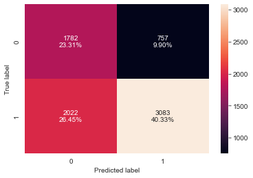

```python
# Building a confusion matrix for the decision tree estimator
confusion_matrix_sklearn(dtree_estimator, X_test, y_test)
```

```python
# Decision Tree Estimator Model Performance Metrics on Training Data
dtree_estimator_model_train_perf = model_performance_classification_sklearn(dtree_estimator, X_train, y_train)
print("Training performance \n", dtree_estimator_model_train_perf)
```

```
Training performance
    Accuracy    Recall  Precision        F1
0  0.640446  0.605977   0.807675  0.692437
```

```python
# Decision Tree Estimator Model Performance Metrics on Test Data
dtree_estimator_model_test_perf = model_performance_classification_sklearn(dtree_estimator, X_test, y_test)
print("Testing performance \n", dtree_estimator_model_test_perf)
```

```
Testing performance
    Accuracy    Recall  Precision        F1
0  0.636447  0.603918   0.802865  0.689324
```

### The decision tree estimator does poorly on training data compared to the non-tuned decision tree. The metrics are identical on both training and test data suggesting the model is generalized. Except for Precision, the decision tree estimator does worse on test data than the non-tuned decision tree.

### Tuning the Bagging Classifier

```python
# Grid search for bagging classifier
cl1 = DecisionTreeClassifier(class_weight = {0:0.67, 1:0.33}, random_state = 1)
param_grid = {'base_estimator':[cl1],
              'n_estimators':[51, 101],
              'max_features': [0.9, 1]
             }

grid = GridSearchCV(BaggingClassifier(random_state = 1,bootstrap = True), param_grid = param_grid, scoring = 'recall', cv = 5)
grid.fit(X_train, y_train)
```

```
GridSearchCV(cv=5, estimator=BaggingClassifier(random_state=1),
             param_grid={'base_estimator': [DecisionTreeClassifier(class_weight={0: 0.67,
                                                                                 1: 0.33},
                                                                   random_state=1)],
                         'max_features': [0.9, 1], 'n_estimators': [51, 101]},
             scoring='recall')
```

```python
# Getting the best esimator
bagging_estimator = grid.best_estimator_
bagging_estimator.fit(X_train, y_train)
```

```
BaggingClassifier(base_estimator=DecisionTreeClassifier(class_weight={0: 0.67,
                                                                      1: 0.33},
                                                        random_state=1),
                  max_features=0.9, n_estimators=101, random_state=1)
```

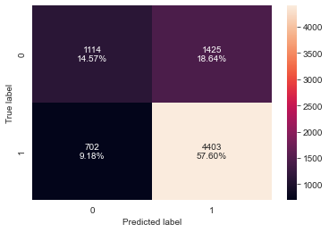

```python
# Building a confusion matrix for the bagging estimator
confusion_matrix_sklearn(bagging_estimator, X_test,y_test)
```

```python
# Bagging Estimator Model Performance Metrics on Training Data
bagging_estimator_model_train_perf = model_performance_classification_sklearn(bagging_estimator, X_train, y_train)
print("Training performance \n", bagging_estimator_model_train_perf)
```

```
Training performance
    Accuracy  Recall  Precision   F1
0       1.0     1.0        1.0  1.0
```

```python
# Bagging Estimator Model Performance Metrics on Test Data
bagging_estimator_model_test_perf = model_performance_classification_sklearn(bagging_estimator, X_test, y_test)
print("Testing performance \n", bagging_estimator_model_test_perf)
```

```
Testing performance
    Accuracy    Recall  Precision        F1
0  0.721743  0.862488   0.755491  0.805451
```

### The bagging estimator does well on training data (slightly better than the non-tuned bagging model and suggesting the model is overfitting). The bagging estimator doesn't generalize well on the test data concerning Accuracy, Recall, Precision, and F1. There is a steep drop off in those metrics when compared to the the results on the training data. Its performance is slightly better than the non-tuned bagging classifier.

### Tuning the Random Forest

```python
# Choose the type of classifier.
rf_estimator = RandomForestClassifier(class_weight = {0:0.67, 1:0.33}, random_state = 1)

# Grid of parameters to choose from
parameters = {
        "n_estimators": [251, 501],
        "min_samples_leaf": np.arange(1, 6, 1),
        "max_features": ['log2', 'auto'],
        "max_samples": [0.9, None],
        "min_impurity_decrease": [0.01, 0.1],
}

# Run the grid search
grid_obj = GridSearchCV(rf_estimator, parameters, scoring = 'recall', cv = 5)
grid_obj = grid_obj.fit(X_train, y_train)

# Set the clf to the best combination of parameters
rf_estimator = grid_obj.best_estimator_

# Fit the best algorithm to the data.
rf_estimator.fit(X_train, y_train)
```

```
RandomForestClassifier(class_weight={0: 0.67, 1: 0.33}, max_features='log2',
                       max_samples=0.9, min_impurity_decrease=0.01,
                       n_estimators=501, random_state=1)
```

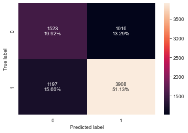

```python
# Building a confusion matrix for the random forest estimator
confusion_matrix_sklearn(rf_estimator, X_test, y_test)
```

```python
# Random Forest Estimator Model Performance Metrics on Training Data
rf_estimator_model_train_perf = model_performance_classification_sklearn(rf_estimator, X_train, y_train)
print("Training performance \n", rf_estimator_model_train_perf)
```

```
Training performance
    Accuracy    Recall  Precision        F1
0  0.710529  0.762444   0.795638  0.778687
```

```python
# Random Forest Estimator Model Performance Metrics on Test Data
rf_estimator_model_test_perf = model_performance_classification_sklearn(rf_estimator, X_test, y_test)
print("Testing performance \n", rf_estimator_model_test_perf)
```

```
Testing performance
    Accuracy    Recall  Precision       F1
0  0.710492  0.765524   0.793664  0.77934
```

### The random forest estimator does okay on training data. The metrics are identical on both training and test data suggesting the model is generalizing well. The random forest estimator does worse than the non-tuned random forest model on training data and a little worse than the non-tuned one on test data.

## Boosting

### Tuning AdaBoost

```python
# Choose the type of classifier.
abc_tuned = AdaBoostClassifier(random_state = 1)

# Grid of parameters to choose from
parameters = {
    "n_estimators": np.arange(10, 110, 10),
    "learning_rate":np.arange(0.1, 2, 0.1)
}

# Type of scoring used to compare parameter  combinations
scorer = metrics.make_scorer(metrics.f1_score)

# Run the grid search
grid_obj = GridSearchCV(abc_tuned, parameters, scoring = scorer, cv = 5)
grid_obj = grid_obj.fit(X_train, y_train)

# Set the clf to the best combination of parameters
abc_tuned = grid_obj.best_estimator_

# Fit the best algorithm to the data.
abc_tuned.fit(X_train, y_train)
```

```
AdaBoostClassifier(learning_rate=0.6, n_estimators=20, random_state=1)
```

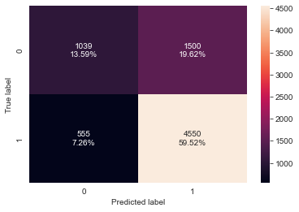

```python
# Building a confusion matrix for the tuned AdaBoost
confusion_matrix_sklearn(abc_tuned, X_test, y_test)
```

```python
# AdaBoost Tuned Model Performance Metrics on Training Data
abc_tuned_model_train_perf = model_performance_classification_sklearn(abc_tuned, X_train, y_train)
print("Training performance \n", abc_tuned_model_train_perf)
```

```
Training performance
    Accuracy    Recall  Precision        F1
0  0.737665  0.895073    0.75667  0.820073
```

```python
# AdaBoost Tuned  Model Performance Metrics on Test Data
abc_tuned_model_test_perf = model_performance_classification_sklearn(abc_tuned, X_test, y_test)
print("Testing performance \n", abc_tuned_model_test_perf)
```

```
Testing performance
    Accuracy    Recall  Precision        F1
0  0.731162  0.891283   0.752066  0.815778
```

### The AdaBoost Tuned Classifier does okay on training data. The metrics are identical on both training and test data, suggesting the model is well generalized. However, the AdaBoost Tuned performs about the same as the non-tuned AdaBoost.

### Tuning GradientBoost

```python
# Choose the type of classifier.
gbc_tuned = GradientBoostingClassifier(init = AdaBoostClassifier(random_state = 1), random_state = 1)

# Grid of parameters to choose from
parameters = {
    "n_estimators": [200, 250],
    "subsample":[0.9, 1],
    "max_features":[0.9, 1]
}

# Type of scoring used to compare parameter combinations
scorer = metrics.make_scorer(metrics.f1_score)

# Run the grid search
grid_obj = GridSearchCV(gbc_tuned, parameters, scoring = scorer, cv = 5)
grid_obj = grid_obj.fit(X_train, y_train)

# Set the clf to the best combination of parameters
gbc_tuned = grid_obj.best_estimator_

# Fit the best algorithm to the data.
gbc_tuned.fit(X_train, y_train)
```

```
GradientBoostingClassifier(init=AdaBoostClassifier(random_state=1),
                           max_features=0.9, n_estimators=200, random_state=1,
                           subsample=0.9)
```

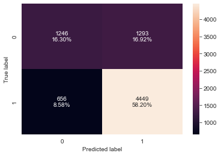

```python
# Building a confusion matrix for the tuned GradientBoost
confusion_matrix_sklearn(gbc_tuned, X_test, y_test)
```

```python
# GradientBoost Tuned Model Performance Metrics on Training Data
gbc_tuned_model_train_perf = model_performance_classification_sklearn(gbc_tuned, X_train, y_train)
print("Training performance:\n", gbc_tuned_model_train_perf)
```

```
Training performance:
    Accuracy    Recall  Precision        F1
0  0.764802  0.884076    0.78915  0.833921
```

```python
# GradientBoost Tuned Model Performance Metrics on Testing Data
gbc_tuned_model_test_perf = model_performance_classification_sklearn(gbc_tuned, X_test, y_test)
print("Testing performance:\n", gbc_tuned_model_test_perf)
```

```
Testing performance:
    Accuracy    Recall  Precision        F1
0  0.745029  0.871499   0.774817  0.820319
```

### The GradientBoost Tuned Classifier does okay on training data. The metrics are identical on both training and test data, suggesting the model is well generalized. However, the GradientBoost Tuned performs about the same as the non-tuned GradientBoost.

## XGBoost Tuning

```python
# Choose the type of classifier.
xgb_tuned = XGBClassifier(random_state = 1, eval_metric = 'logloss')

# Grid of parameters to choose from
parameters = {
    "n_estimators": [30, 50],
    "scale_pos_weight":[2, 5],
    "subsample":[0.9, 1],
    "learning_rate":[0.1, 0.2],
    "colsample_bytree":[0.9, 1],
    "colsample_bylevel":[0.7, 1]
}

# Type of scoring used to compare parameter combinations
scorer = metrics.make_scorer(metrics.f1_score)

# Run the grid search
grid_obj = GridSearchCV(xgb_tuned, parameters, scoring = scorer, cv = 5)
grid_obj = grid_obj.fit(X_train, y_train)

# Set the clf to the best combination of parameters
xgb_tuned = grid_obj.best_estimator_

# Fit the best algorithm to the data.
xgb_tuned.fit(X_train, y_train)
```

```
XGBClassifier(base_score=0.5, booster='gbtree', colsample_bylevel=1,
              colsample_bynode=1, colsample_bytree=1, enable_categorical=False,
              eval_metric='logloss', gamma=0, gpu_id=-1, importance_type=None,
              interaction_constraints='', learning_rate=0.1, max_delta_step=0,
              max_depth=6, min_child_weight=1, missing=nan,
              monotone_constraints='()', n_estimators=50, n_jobs=12,
              num_parallel_tree=1, predictor='auto', random_state=1,
              reg_alpha=0, reg_lambda=1, scale_pos_weight=2, subsample=1,
              tree_method='exact', validate_parameters=1, verbosity=None)
```

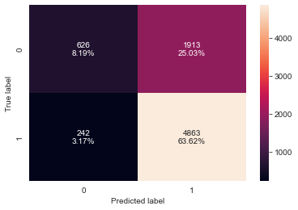

```python
# Building a confusion matrix for the tuned XGBoost
confusion_matrix_sklearn(xgb_tuned, X_test, y_test)
```

```python
# XGBoost Tuned Model Performance Metrics on Training Data
xgb_tuned_model_train_perf = model_performance_classification_sklearn(xgb_tuned, X_train, y_train)
print("Training performance:\n", xgb_tuned_model_train_perf)
```

```
Training performance:
    Accuracy    Recall  Precision       F1
0  0.752299  0.975237   0.738073  0.84024
```

```python
# XGBoost Tuned Model Performance Metrics on Testing Data
xgb_tuned_model_test_perf = model_performance_classification_sklearn(xgb_tuned, X_test, y_test)
print("Testing performance:\n", xgb_tuned_model_test_perf)
```

```
Testing performance:
    Accuracy    Recall  Precision        F1
0   0.71808  0.952595    0.71768  0.818618
```

## Stacking Classifier

```python
# Building and fitting stacking classifier
estimators = [("Random Forest", rf_estimator), ("Gradient Boosting", gbc_tuned), ("Decision Tree", dtree_estimator)]

final_estimator = xgb_tuned

stacking_classifier = StackingClassifier(estimators = estimators, final_estimator = final_estimator)

stacking_classifier.fit(X_train, y_train)
```

```
StackingClassifier(estimators=[('Random Forest',
                                RandomForestClassifier(class_weight={0: 0.67,
                                                                     1: 0.33},
                                                       max_features='log2',
                                                       max_samples=0.9,
                                                       min_impurity_decrease=0.01,
                                                       n_estimators=501,
                                                       random_state=1)),
                               ('Gradient Boosting',
                                GradientBoostingClassifier(init=AdaBoostClassifier(random_state=1),
                                                           max_features=0.9,
                                                           n_estimators=200,
                                                           random_state=1,
                                                           subsample=0.9)),
                               ('...
                                                 gpu_id=-1,
                                                 importance_type=None,
                                                 interaction_constraints='',
                                                 learning_rate=0.1,
                                                 max_delta_step=0, max_depth=6,
                                                 min_child_weight=1,
                                                 missing=nan,
                                                 monotone_constraints='()',
                                                 n_estimators=50, n_jobs=12,
                                                 num_parallel_tree=1,
                                                 predictor='auto',
                                                 random_state=1, reg_alpha=0,
                                                 reg_lambda=1,
                                                 scale_pos_weight=2,
                                                 subsample=1,
                                                 tree_method='exact',
                                                 validate_parameters=1,
                                                 verbosity=None))
```

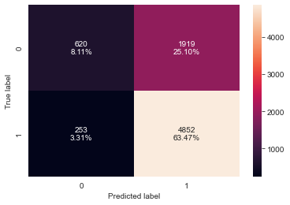

```python
# Building a confusion matrix for the stacking classifier
confusion_matrix_sklearn(stacking_classifier, X_test, y_test)
```

```python
# Stacking Classifier Model Performance Metrics on Training Data
stacking_classifier_model_train_perf = model_performance_classification_sklearn(stacking_classifier, X_train, y_train)
print("Training performance:\n", stacking_classifier_model_train_perf)
```

```
Training performance:
    Accuracy    Recall  Precision        F1
0  0.730433  0.955679   0.726779  0.825658
```

```python
# Stacking Classifier Model Performance Metrics on Testing Data
stacking_classifier_model_test_perf = model_performance_classification_sklearn(stacking_classifier, X_test, y_test)
print("Testing performance:\n", stacking_classifier_model_test_perf)
```

```
Testing performance:
    Accuracy    Recall  Precision       F1
0  0.715856  0.950441   0.716585  0.81711
```

### The Stacking Classifier does okay on training data. The metrics are pretty similar on the test data compared to the training data, suggesting the model is well generalized. The Stacking Classifier has an identical F1 score on test data to the XGBoost Tuned Classifier.

## Model Performance Comparison and Conclusions

```python
# Summary of metrics from models on training data

models_train_comp_df = pd.concat(
    [dtree_model_train_perf.T, bagging_model_train_perf.T, bagging_wt_model_train_perf.T, rf_model_train_perf.T, rf_wt_model_train_perf.T,
     dtree_estimator_model_train_perf.T, bagging_estimator_model_train_perf.T, rf_estimator_model_train_perf.T, ab_classifier_model_train_perf.T,
     gb_classifier_model_train_perf.T, xgb_classifier_model_train_perf.T, abc_tuned_model_train_perf.T, gbc_tuned_model_train_perf.T,
     xgb_tuned_model_train_perf.T, stacking_classifier_model_train_perf.T
],
    axis = 1,
)
models_train_comp_df.columns = [
    "Decision Tree",
    "Bagging Classifier",
    "Weighted Bagging Classifier",
    "Random Forest Classifier",
    "Weighted Random Forest Classifier",
    "Decision Tree Estimator",
    "Bagging Estimator",
    "Random Forest Estimator",
    "AdaBoost Classifier",
    "GradientBoost Classifier",
    "XGBoost Classifier",
    "AdaBoost Tuned",
    "GradientBoost Tuned",
    "XGBoost Tuned",
    "Stacking Classifier"]
print("Training performance comparison:")
models_train_comp_df
```

```
Training performance comparison:
```

|  | Decision Tree | Bagging Classifier | Weighted Bagging Classifier | Random Forest Classifier | Weighted Random Forest Classifier | Decision Tree Estimator | Bagging Estimator | Random Forest Estimator | AdaBoost Classifier | GradientBoost Classifier | XGBoost Classifier | AdaBoost Tuned | GradientBoost Tuned | XGBoost Tuned | Stacking Classifier |
| --- | --- | --- | --- | --- | --- | --- | --- | --- | --- | --- | --- | --- | --- | --- | --- |
| Accuracy | 1.0 | 0.985198 | 0.985479 | 0.999944 | 1.0 | 0.640446 | 1.0 | 0.710529 | 0.738226 | 0.758802 | 0.838753 | 0.737665 | 0.764802 | 0.752299 | 0.730433 |
| Recall | 1.0 | 0.985982 | 0.987241 | 0.999916 | 1.0 | 0.605977 | 1.0 | 0.762444 | 0.887182 | 0.883740 | 0.931419 | 0.895073 | 0.884076 | 0.975237 | 0.955679 |
| Precision | 1.0 | 0.991810 | 0.990984 | 1.000000 | 1.0 | 0.807675 | 1.0 | 0.795638 | 0.760688 | 0.783042 | 0.843482 | 0.756670 | 0.789150 | 0.738073 | 0.726779 |
| F1 | 1.0 | 0.988887 | 0.989109 | 0.999958 | 1.0 | 0.692437 | 1.0 | 0.778687 | 0.819080 | 0.830349 | 0.885272 | 0.820073 | 0.833921 | 0.840240 | 0.825658 |

```python
# Test performance comparison

models_test_comp_df = pd.concat(
    [dtree_model_test_perf.T, bagging_model_test_perf.T, bagging_wt_model_test_perf.T, rf_model_test_perf.T, rf_wt_model_test_perf.T,
     dtree_estimator_model_test_perf.T, bagging_estimator_model_test_perf.T, rf_estimator_model_test_perf.T, ab_classifier_model_test_perf.T,
     gb_classifier_model_test_perf.T, xgb_classifier_model_test_perf.T, abc_tuned_model_test_perf.T, gbc_tuned_model_test_perf.T,
     xgb_tuned_model_test_perf.T, stacking_classifier_model_test_perf.T
],
    axis = 1,
)
models_test_comp_df.columns = [
    "Decision Tree",
    "Bagging Classifier",
    "Weighted Bagging Classifier",
    "Random Forest Classifier",
    "Weighted Random Forest Classifier",
    "Decision Tree Estimator",
    "Bagging Estimator",
    "Random Forest Estimator",
    "AdaBoost Classifier",
    "GradientBoost Classifier",
    "XGBoost Classifier",
    "AdaBoost Tuned",
    "GradientBoost Tuned",
    "XGBoost Tuned",
    "Stacking Classifier"]
print("Test performance comparison:")
models_test_comp_df
```

```
Test performance comparison:
```

|  | Decision Tree | Bagging Classifier | Weighted Bagging Classifier | Random Forest Classifier | Weighted Random Forest Classifier | Decision Tree Estimator | Bagging Estimator | Random Forest Estimator | AdaBoost Classifier | GradientBoost Classifier | XGBoost Classifier | AdaBoost Tuned | GradientBoost Tuned | XGBoost Tuned | Stacking Classifier |
| --- | --- | --- | --- | --- | --- | --- | --- | --- | --- | --- | --- | --- | --- | --- | --- |
| Accuracy | 0.653715 | 0.691523 | 0.695709 | 0.720827 | 0.723182 | 0.636447 | 0.721743 | 0.710492 | 0.734301 | 0.744767 | 0.733255 | 0.731162 | 0.745029 | 0.718080 | 0.715856 |
| Recall | 0.749265 | 0.764153 | 0.778844 | 0.832125 | 0.842703 | 0.603918 | 0.862488 | 0.765524 | 0.885015 | 0.876004 | 0.860725 | 0.891283 | 0.871499 | 0.952595 | 0.950441 |
| Precision | 0.736710 | 0.771711 | 0.768606 | 0.768869 | 0.766162 | 0.802865 | 0.755491 | 0.793664 | 0.757799 | 0.772366 | 0.767913 | 0.752066 | 0.774817 | 0.717680 | 0.716585 |
| F1 | 0.742935 | 0.767913 | 0.773691 | 0.799247 | 0.802612 | 0.689324 | 0.805451 | 0.779340 | 0.816481 | 0.820927 | 0.811675 | 0.815778 | 0.820319 | 0.818618 | 0.817110 |

### Feature Importances of GradientBoost Classifier

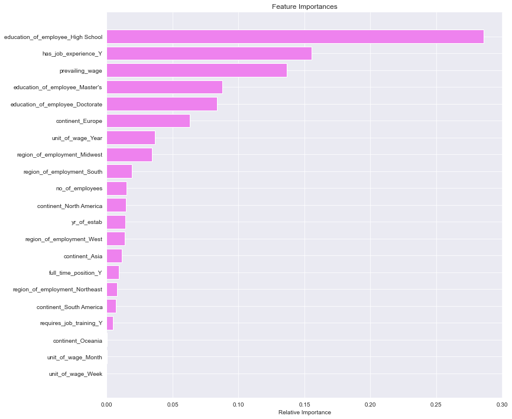

```python
feature_names = X_train.columns
importances = gb_classifier.feature_importances_
indices = np.argsort(importances)

plt.figure(figsize=(12,12))
plt.title('Feature Importances')
plt.barh(range(len(indices)), importances[indices], color = 'violet', align = 'center')
plt.yticks(range(len(indices)), [feature_names[i] for i in indices])
plt.xlabel('Relative Importance')
plt.show()
```

### The top three features that impact whether a visa application is approved or denied are 1) education_of_employee_High School, 2) has_job_experience_Y, and 3) prevailing_wage respectively.

## Actionable Insights and Recommendations

*To increase the chances of a visa getting approved*